# 산업공학특론I_중간고사

김윤희 (2021118105)

4/10/2024

### [중간고사 개요]

#### 1. 중간고사 답안 작성 및 제출 요령

- 모든 답안 도출 과정은 R 코드로 작성되어야 하며, 코드에는 분석 과정을 식별할 수 있도록 주석(#)으로 설명이 작성되어야 한다. (R 코드 없이 답만 적는 경우 오답 처리)
- 수강생 간 코드를 공유하거나 동일하게 작성하는 행위를 금지한다. (적발 시 진실의 방 소환 및 모두 0점으로 성적 반영)
- 특정한 문제에 대한 답안은 해당 문항에 대한 코드에 작성되어야 한다. (1번 문항에 대한 답을 2번 문항에 적는 경우 오답 처리)
- 답안은 Rmd 확장자로 보고서 제작이 가능하도록 제출하는 것을 원칙으로 하나, Markdown 실행이 어려운 경우 R 스크립트로 작성하되 채점이 가능하도록 문항 별로 스크립트를 작성하여야 한다.
- 중간고사 답안은 4월 10일 23시 59분까지 온라인 강의실 내 과제 및 평가 - 중간고사 탭에 제출하여야 하며, 4월 11일 자정 이후에는 제출이 불가하다. (이후 다른 경로를 통하여 제출 시 총점의 50%로 성적 반영)

#### 2. 데이터 설명

어느 의류 생산 공정에서는 재봉 (sewing), 마감 (finishing)으로 부서를 구성하여 공정을 운영하고 있으며, 공정의 생산성을 개선하기 위해 일별 공정 작업 관련 데이터를 수집하여 생산성에 영향을 미치는 요인을 분석하고자 한다. 데이터 분석에 활용하는 변수의 정보는 다음과 같다.

- date: 집계 날짜
- quarter: 한 달을 나눈 분기 (주)
- department: 부서
- day: 요일
- team: 부서별 투입 인원 수
- targeted_productivity: 당초에 목표한 생산성 점수
- over_time: 초과근무 (분)
- incentive: 성과급
- actual_productivity: 실제 생산성 점수

상기에 기술된 작성요령과 데이터를 기반으로 주어진 문제에 대한 분석 과정과 그에 따른 답안을 기술하시오.

### [중간고사 문항]

#### 1. 주어진 데이터에서 데이터 탐색 (EDA) 및 전처리를 수행하고, 결과를 시각화하시오. (10점)

- 활용하지 않는 변수 (date, smv, wip, idle_time, idle_men, no_of_style_change, no_of_workers)는 삭제할 것
- 시각화 시 범주형 변수는 막대그래프로, 연속형 변수는 히스토그램으로 표현할 것

```r
# 사용할 데이터 입력
dat <- read.csv("산업공학특론I_중간고사 데이터.csv")

# 활용하지 않는 변수 삭제
column_name <- c("date", "smv", "wip", "idle_time", "idle_men", "no_of_style_change", "no_of_workers")
dat <- subset(dat, select = setdiff(names(dat), column_name))

# 범주형 변수로 변경(분기, 요일, 부서)
dat$quarter <- as.factor(dat$quarter)
# 부서의 경우, 마감파트의 전처리가 필요하여 전처리 과정 추가
dat$department <- ifelse(dat$department == 'sweing', 'sweing', 'finishing')
dat$department <- as.factor(dat$department)
dat$day <- as.factor(dat$day)

summary(dat)
```

```
##      quarter        department         day           team
##  Quarter1:360   finishing:506   Monday   :199   Min.   : 1.000
##  Quarter2:335   sweing   :691   Saturday :187   1st Qu.: 3.000
##  Quarter3:210                   Sunday   :203   Median : 6.000
##  Quarter4:248                   Thursday :199   Mean   : 6.427
##  Quarter5: 44                   Tuesday  :201   3rd Qu.: 9.000
##                                 Wednesday:208   Max.   :12.000
##  targeted_productivity   over_time       incentive       actual_productivity
##  Min.   :0.0700        Min.   :    0   Min.   :   0.00   Min.   :0.2337
##  1st Qu.:0.7000        1st Qu.: 1440   1st Qu.:   0.00   1st Qu.:0.6503
##  Median :0.7500        Median : 3960   Median :   0.00   Median :0.7733
##  Mean   :0.7296        Mean   : 4567   Mean   :  38.21   Mean   :0.7351
##  3rd Qu.:0.8000        3rd Qu.: 6960   3rd Qu.:  50.00   3rd Qu.:0.8503
##  Max.   :0.8000        Max.   :25920   Max.   :3600.00   Max.   :1.1204
```

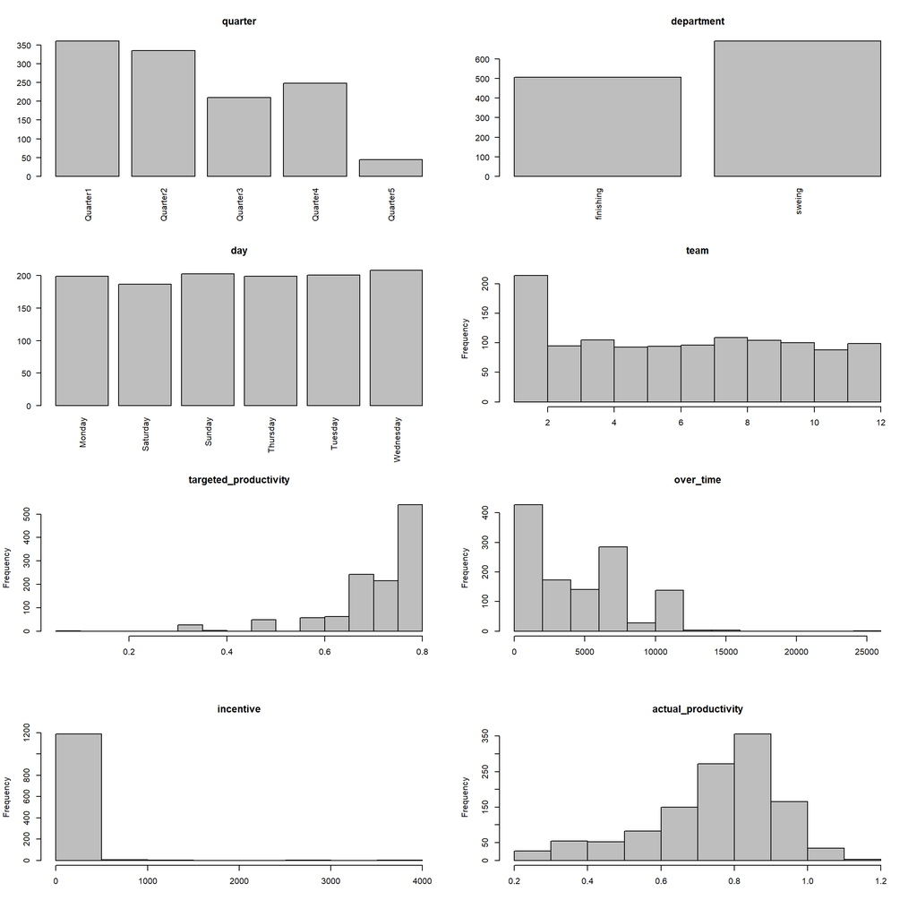

```r
# 범주형은 막대로, 연속형은 히스토그램으로 시각화 함수 선언
visualize <- function(x,main){
  if (is.factor(x)){
    barplot(table(x), col='grey', main=main, las=2)
  }else{
    hist(x, col='grey', main=main, xlab='')
    }
}

# 4행 2열 배치로 시각화 진행
par(mfrow=c(4,2))
for (i in 1:ncol(dat)){
  visualize(x=dat[,i], main=colnames(dat)[i])
  }
```

#### 2. 실제 생산성 점수 (actual_productivity)가 어떠한 분포를 따르는지 규명하기 위하여 여러 분포에 대한 MLE를 추정 및 비교하고, 최적 분포를 도출하시오. (15점)

- 여러 분포 (최소 2개 이상)에 대하여 MLE를 통하여 모수를 추정할 것
- 분포별 추정 결과 비교 시 적합도 평가 지표를 활용할 것
- 추정 결과에 따른 최적 분포를 도출하고, 그 근거를 제시할 것

```r
library(fitdistrplus)
```

```
## Fitting of the distribution ' exp ' by maximum likelihood
## Parameters:
##      estimate Std. Error
## rate 1.360376 0.03931982
## Fitting of the distribution ' gamma ' by maximum likelihood
## Parameters:
##       estimate Std. Error
## shape 13.98194  0.5648385
## rate  19.02084  0.7823388
## Fitting of the distribution ' norm ' by maximum likelihood
## Parameters:
##       estimate  Std. Error
## mean 0.7350911 0.005041233
## sd   0.1744150 0.003564163
## Fitting of the distribution ' weibull ' by maximum likelihood
## Parameters:
##        estimate Std. Error
## shape 5.2193694 0.12356060
## scale 0.7999979 0.00462855
## Fitting of the distribution ' lnorm ' by maximum likelihood
## Parameters:
##           estimate  Std. Error
## meanlog -0.3439459 0.008360773
## sdlog    0.2892634 0.005911641
## [1] "########################################################"
##                 exp      gamma         norm      weibull        lnorm
## par1       1.360376   13.98194    0.7350911    5.2193694   -0.3439459
## par2             NA   19.02084    0.1744150    0.7999979    0.2892634
## loglike -828.610267  277.69735  391.8729179  437.8622469  198.0135927
## AIC     1659.220535 -551.39470 -779.7458357 -871.7244938 -392.0271853
## [1] " 최적 분포는  weibull 입니다."
```

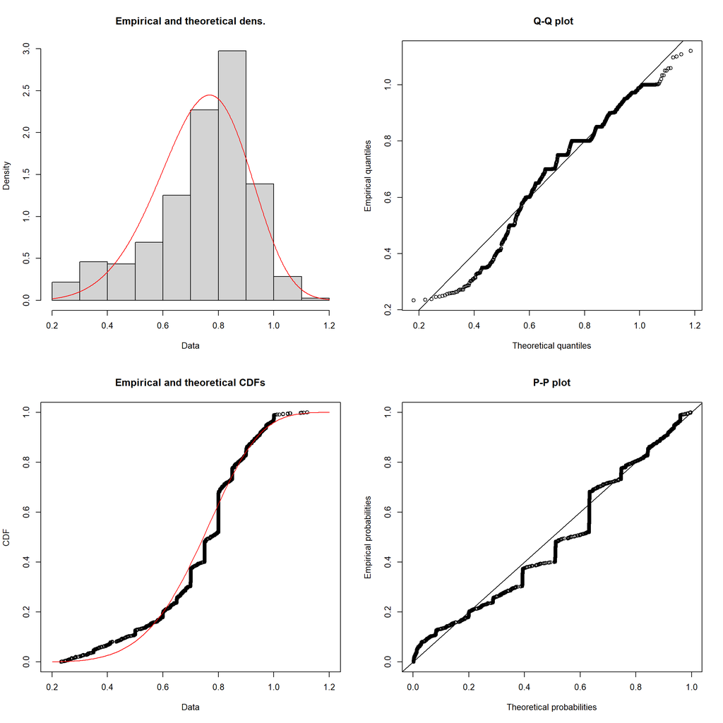

```r
# 확률분포 추정 함수 정의
fit <- function(x){

  # 후보 확률분포 정의
  fitlist <- c('exp','gamma','norm','weibull','lnorm')

  # 추정 파라미터와 로그우도값을 추정한 결과를 정리할 틀 생성
  result <- matrix(nrow=4, ncol=length(fitlist))
  colnames(result) <- fitlist
  row.names(result) <- c('par1','par2','loglike', 'AIC')

  # 지정한 후보 확률분포를 각각 추정하여 결과를 틀에 입력
  for (i in 1:length(fitlist)){
    # 각 분포 적합은 MLE를 기반으로 적합 진행
    fit_temp <- fitdist(x, fitlist[i], method="mle")
    print(fit_temp)
    est <- fit_temp$estimate
    if (length(est)==1){est <- c(est,NA)}

    ll <- fit_temp$loglik
    AIC <- fit_temp$aic
    result[,i] <- c(est, ll, AIC)
  }
  print('########################################################') # 결과 출력
  print(result) # 결과 출력

  # 로그우도값이 가장 큰 확률분포를 적합 분포로 선정하여 출력
  best <- colnames(result)[which.max(result[3,])]
  print(paste(names(x),'최적 분포는 ', best,'입니다.'))
  plot(fitdist(x, best))
  return(result)
}

result <- fit(dat$actual_productivity)
```

```r
result
```

```
##                 exp      gamma         norm      weibull        lnorm
## par1       1.360376   13.98194    0.7350911    5.2193694   -0.3439459
## par2             NA   19.02084    0.1744150    0.7999979    0.2892634
## loglike -828.610267  277.69735  391.8729179  437.8622469  198.0135927
## AIC     1659.220535 -551.39470 -779.7458357 -871.7244938 -392.0271853
```

#### 3. 2. 에서 도출된 최적 분포를 기준으로 MLE 추정 결과를 시각화하고 이를 해석하시오. (10점)

- 시각화의 경우 실제 데이터의 분포와 MLE를 모수로 가지는 분포의 비교가 가능하도록 도시할 것
- 단순 도시가 아닌 도시 결과에 대한 해석 결과를 설명하고, 결론을 도출할 것

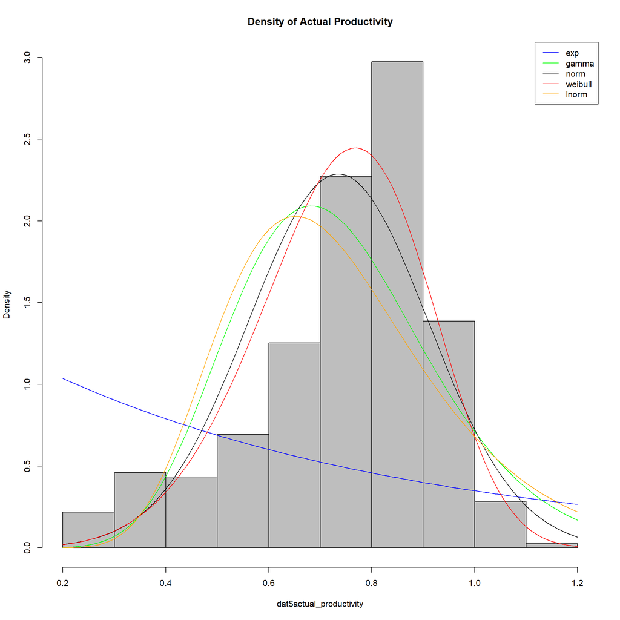

```r
fitlist <- c('exp','gamma','norm','weibull','lnorm')
color <- c('blue','green','black','red','orange')

hist(dat$actual_productivity, col='grey', breaks = 10, main = 'Density of Actual Productivity', prob = T)
curve(dexp(x, rate=result[1,1]), col=color[1], add=T)
curve(dgamma(x, shape=result[1,2], rate=result[2,2]), col=color[2], add=T)
curve(dnorm(x, mean=result[1,3], sd=result[2,3]), col=color[3], add=T)
curve(dweibull(x, shape=result[1,4], scale=result[2,4]), col=color[4], add=T)
curve(dlnorm(x, meanlog=result[1,5], sdlog=result[2,5]), col=color[5], add=T)
legend('topright', legend = fitlist, col=color, lty=1)
```

- MLE 추정을 통해 산출된 추정 결과를 바탕으로 실제 데이터의 히스토그램과 개별 분포의 적합 결과를 도식하면 위와 같다.
- 위의 결과를 통해, MLE 값이 가장 큰 weibull 분포가 실제 데이터와 가장 유사한 형태로 모사하고 있음을 확인할 수 있다.
- 실제 생산성의 데이터 분포 경향성을 확인하면, 오른쪽으로 치우쳐져서 높게 올라가는 형태로 이 형태와 가장 유사한 곡선은 와이블분포이다.
- 또한, 중심경향성과 양쪽 극단 또한 다른 분포들 대비 와이블분포가 가장 유사하게 모사하고 있다는 것을 확인할 수 있다.

#### 4. 주차 (quarter), 부서 (department), 요일 (day) 별로 목표하는 점수 (targeted_productivity), 실제 생산성 점수 (actual_productivity)에 차이가 없는지 그룹화를 수행하고 각 점수에 대해 기술통계량을 검토하시오. (10점)

- 기술통계량은 목표 점수, 실제 점수 모두 검토할 것
- 기술통계량 검토 결과를 해석하여 본인의 생각과 결론을 글로 작성할 것

```r
column_name <- c("quarter","department","day")

# 주차, 부서, 요일의 각 그룹마다 실제 점수와 목표 점수의 차이 검터
# 점수 차이를 검정하기 위해서, 각 그룹마다 실제 점수 및 목표 점수의 평균, 최대, 최소 산출하여 차이 검토

grp_summary <- function(grp) {
  # (1) 그룹으로 데이터 분할
  split_data <- split(dat, dat[grp])

  mean_test <- function(data) {
    actual_mean <- mean(data$actual_productivity)
    target_mean <- mean(data$targeted_productivity)
    # (2) 평균 실제 점수와 평균 목표 점수의 차이 산출
    mean_diff <- actual_mean - target_mean

    # (3) 최소, 최대 산출
    actual_min <- min(data$actual_productivity)
    target_min <- min(data$targeted_productivity)
    actual_max <- max(data$actual_productivity)
    target_max <- max(data$targeted_productivity)

    # (4) 미달성 및 초과달성 산출
    diff_min <- min(data$actual_productivity - data$targeted_productivity)
    diff_max <- max(data$actual_productivity - data$targeted_productivity)

    # (5) 산출결과 저장
    return(list(
      actual_mean = actual_mean,
      target_mean = target_mean,
      mean_diff = mean_diff,
      actual_min = actual_min,
      target_min = target_min,
      actual_max = actual_max,
      target_max = target_max,
      diff_min = diff_min,
      diff_max = diff_max,
      count = nrow(data)
    ))
  }

  # 분할된 데이터 마다 차이 산출 진행
  results <- lapply(split_data, mean_test)

  # 산출된 결과 저장
  result_df <- do.call(rbind, results)

  #그룹 이름으로 열이름 변경
  rownames(result_df) <- unique(dat[[grp]])
  print(result_df)
}

for (i in 1:(length(column_name))){
  print(column_name[i])
  grp_summary(i)
}
```

```
## [1] "quarter"
##          actual_mean target_mean mean_diff    actual_min target_min actual_max
## Quarter1 0.7515598   0.7440833   0.007476448  0.2609788  0.07       1.050667
## Quarter2 0.7437097   0.7320896   0.01162018   0.2337055  0.35       1.100484
## Quarter3 0.7047586   0.7211905   -0.01643186  0.2357955  0.35       1.120437
## Quarter4 0.7090671   0.7145161   -0.005449005 0.259375   0.35       1.059621
## Quarter5 0.8261774   0.7181818   0.1079956    0.2869846  0.5        1.000457
##          target_max diff_min   diff_max  count
## Quarter1 0.8        -0.4576389 0.45575   360
## Quarter2 0.8        -0.5619583 0.644375  335
## Quarter3 0.8        -0.4861472 0.6386364 210
## Quarter4 0.8        -0.4924985 0.6275556 248
## Quarter5 0.8        -0.3111696 0.399     44
## [1] "department"
##           actual_mean target_mean mean_diff    actual_min target_min actual_max
## sweing    0.7529507   0.7373518   0.01559889   0.2357955  0.35       1.120437
## finishing 0.722013    0.7239797   -0.001966708 0.2337055  0.07       1.100484
##           target_max diff_min   diff_max  count
## sweing    0.8        -0.5619583 0.644375  506
## finishing 0.8        -0.4924985 0.4528448 691
## [1] "day"
##           actual_mean target_mean mean_diff    actual_min target_min actual_max
## Thursday  0.7354885   0.729397    0.006091514  0.24625    0.35       1.059621
## Saturday  0.7519289   0.7336898   0.01823902   0.2380417  0.35       1.050667
## Sunday    0.7286041   0.7374384   -0.008834295 0.2357955  0.5        1.120437
## Monday    0.7226409   0.7207035   0.001937364  0.2337055  0.07       1.100484
## Tuesday   0.7427009   0.7276119   0.01508898   0.2682143  0.35       1.03357
## Wednesday 0.7304619   0.7290865   0.00137537   0.247316   0.35       1.050281
##           target_max diff_min   diff_max  count
## Thursday  0.8        -0.55375   0.5922138 199
## Saturday  0.8        -0.5619583 0.45575   187
## Sunday    0.8        -0.4924985 0.3721    203
## Monday    0.8        -0.478125  0.6386364 199
## Tuesday   0.8        -0.4406667 0.6020202 201
## Wednesday 0.8        -0.552684  0.644375  208
```

##### 요일

- 7일 중 6일 생산하며, 토요일이 187로 근무횟수가 가장 적고 수요일이 208로 근무횟수가 가장 많으며 금요일은 휴일임을 확인할 수 있다.
- 평균적으로 대부분의 요일에서 목표을 달성하였지만, 일요일의 경우 -0.008로 목표달성하지 못했음을 확인할 수 있다.
- 일요일의 경우, 다들 날 대비 최소 목표가 0.5 높다는 것을 확인할 수 있다.

#### 5. 부서 (department) 별로 실제 생산성 점수 (actual_productivity)의 분포에 차이가 있다고 볼 수 있는지 검정하고자 한다. 신뢰수준 99% 하에서 모평균, 모분산 가설검정을 수행하시오. (10점)

- 가설검정을 수행할 때에는 5단계의 절차를 준용하여 코드 및 설명을 작성할 것
- 모평균 검정 시 모분산은 알려지지 않았으며, 부서별 생산성 점수의 모분산은 다르다고 가정

```r
library(nortest)

# (1) 귀무가설 및 대립가설 설정
# 귀무가설1 : 재봉부서 평균과 마감부서 평균이 동일
# 귀무가설2 : 재봉부서 분산과 마감부서 분산이 동일
# (2) 유의수준 설정 : 0.01으로 양측검정 진행

# (3) 분포 및 기각역 설정
# 앞서 진행한 분포의 경우, 와이블분포에 적합함을 확인
# t.test 진행을 위해서는 정규성 검정 필요
Normal.test <- function(data){
  m <- mean(data$actual_productivity)
  sd <- sd(data$actual_productivity)
  data <- (data$actual_productivity - m)/sd

  print(ks.test(data, "pnorm"))
  print(ad.test(data))
}

# 정규성 검정을 통과하지 못하므로 다른 검정 방식이 필요함을 확인
split_data <- split(subset(dat, select = c("actual_productivity")), dat["department"])
lapply(split_data, Normal.test)
```

```
##
##  Asymptotic one-sample Kolmogorov-Smirnov test
##
## data:  data
## D = 0.11516, p-value = 2.968e-06
## alternative hypothesis: two-sided
##
##
##  Anderson-Darling normality test
##
## data:  data
## A = 11.126, p-value < 2.2e-16
```

```
##
##  Asymptotic one-sample Kolmogorov-Smirnov test
##
## data:  data
## D = 0.17708, p-value < 2.2e-16
## alternative hypothesis: two-sided
##
##
##  Anderson-Darling normality test
##
## data:  data
## A = 24.944, p-value < 2.2e-16
```

```
## $finishing
##
##  Anderson-Darling normality test
##
## data:  data
## A = 11.126, p-value < 2.2e-16
##
##
## $sweing
##
##  Anderson-Darling normality test
##
## data:  data
## A = 24.944, p-value < 2.2e-16
```

```r
# But, 데이터의 크기가 충분히 크기 때문에 정규성을 가정할 수 있음
# 정규성을 가정한 경우, 아래와 같은 결과를 만들 수 있음

# [정규성 가정]
# (3-1) 독립 표본 t 검정(H0 : 재봉과 마감의 생산성은 동일하다)
# 정규분포 및 불등분산 가정 기반으로 t 검정 진행
t.t.F <- t.test(split_data$finishing, split_data$sweing, var.equal=FALSE, conf.level=0.99)

# (4-1) 검정통계량 계산
# (5-1) 결과 도출 : p-value는 0.005(양측검정)보다 작으므로 귀무가설을 기각하여 두 평균이 다르다는 것을 확인
print("두 분포의 평균 검정")
```

```
## [1] "두 분포의 평균 검정"
```

```r
print(paste('검정통계량 t_0 : ',t.t.F$statistic))
```

```
## [1] "검정통계량 t_0 :  2.93138162701574"
```

```r
print(paste('p-value = ',t.t.F$p.value))
```

```
## [1] "p-value =  0.00345756237945364"
```

```r
# (3-2) 독립 표본 F 검정(H0 : 재봉과 마감의 생산성은 다르다)
# 정규분포 및 불등분산 가정 기반으로 t 검정 진행
v.t <- var.test(unlist(split_data$finishing), unlist(split_data$sweing), conf.level = 0.99)

# (4-1) 검정통계량 계산
# (5-1) 결과 도출 : p-value는 0.005(양측검정)보다 작으므로 귀무가설을 기각하여 두 분산이 다르다는 것을 확인
print("두 분포의 분산 검정")
```

```
## [1] "두 분포의 분산 검정"
```

```r
print(paste('검정통계량 F_0 : ',v.t$statistic))
```

```
## [1] "검정통계량 F_0 :  1.62020898303069"
```

```r
print(paste('p-value = ',v.t$p.value))
```

```
## [1] "p-value =  4.27112878398361e-09"
```

#### 6. 부서에 따라 목표 생산성 점수 (targeted_productivity) 대비 실제로 달성한 생산성 점수 (actual_productivity)를 초과하는 비율에 차이가 있는지 살펴보고자 한다. 부서 (department) 별로 목표량을 초과하여 생산이 이루어진 비율에 차이가 있는지 95% 신뢰수준 하에서 검정을 수행하고, 달성 비율 차이에 대한 신뢰구간을 산출하시오. (15점)

- 부서별 전체 데이터 중 목표 생산성 점수가 실제 생산성 점수를 초과하는 비율이 같은지 비교할 것

```r
# 목표 생산성 점수 대비 실제로 달성한 생산성 점수 비율을 부서별로 분할
dat_prob <- split(dat$actual_productivity/dat$targeted_productivity,dat["department"])
# 부할된 결과 중 1이상(목표량 초과 생산)의 경우의 비율의 차가 있는지 검정
ndat <- sapply(dat_prob, length)
np <- sapply(dat_prob, function(x){ sum(x>=1) })
p.t <- prop.test(np, ndat, conf.level = 0.95)

# 검정 결과에 따라, 매우 작은 p-value 값을 통하여 두 부서의 초과 생산 비율은 동일하지 않음을 확인
print(paste('p-value : ', p.t$p.value))
```

```
## [1] "p-value :  6.06174542332827e-19"
```

```r
print(paste("신뢰구간: [", p.t$conf.int[1], ", ", p.t$conf.int[2], "]"))
```

```
## [1] "신뢰구간: [ -0.285233934247158 ,  -0.179556167741711 ]"
```

#### 7. 생산 공정에 투입되는 인원 (team)이 요일 (day)에 관계없이 동일한지 검정하고자 한다. 신뢰수준 95%에서 가설검정을 수행하시오. (15점)

- 요일별로 평균적인 투입 인원을 산출할 것
- 실제 투입 인원이 요일에 관계없이 동일한 경우와 비교하여 가설검정을 수행할 것

```r
# 두 평균을 산출하여 도수와 한 후 검정 진행
dat_day <- split(dat$team, dat$day)
day_sum <- lapply(dat_day, sum)
day_count <- lapply(dat_day, length)
# 기대 도수 산출(전체 평균 * 요일별 근무 횟수)
day_exp <- rep(sum(dat$team)/(nrow(dat)), length(day_sum))
day_exp <- day_exp*unlist(day_count)

chi_squared_stat <- sum(((unlist(day_sum) - day_exp)^2) / day_exp)
df <- length(day_sum) - 1
# p-값 계산
p_value <- pchisq(chi_squared_stat, df, lower.tail = FALSE)

# 검정 수행 결과
# p-value가 0.025보다 크기때문에 요일에 관계없이 동일한 것을 확인할 수 있다.
cat("Chi-squared statistic:", chi_squared_stat, "\n")
```

```
## Chi-squared statistic: 1.068544
```

```r
cat("Degrees of freedom:", df, "\n")
```

```
## Degrees of freedom: 5
```

```r
cat("P-value:", p_value, "\n")
```

```
## P-value: 0.95685
```

```r
# 두 평균으로 검정한 결과
# 요일별 실제 투입 인원 평균 산출
day_mean <- as.data.frame(lapply(dat_day, mean))
# 전체 근무 횟수 당 평균 인원 산출
day_exp <- rep(sum(dat$team)/(nrow(dat)), length(day_mean))
day_mean <- rbind(day_mean,day_exp)
print(day_mean)
```

```
##     Monday Saturday   Sunday Thursday  Tuesday Wednesday
## 1 6.577889 6.374332 6.433498 6.336683 6.437811  6.399038
## 2 6.426901 6.426901 6.426901 6.426901 6.426901  6.426901
```

```r
# 검정 수행 결과
# p-value가 0.025보다 크기때문에 요일에 관계없이 동일한 것을 확인할 수 있다.
chisq.test(day_mean)
```

```
##
##  Pearson's Chi-squared test
##
## data:  day_mean
## X-squared = 0.0026797, df = 5, p-value = 1
```

#### 8. 초과근무 시간 (over_time)과 성과급 (incentive)이 연관성이 있는지 가설검정을 통하여 확인하고자 한다. 신뢰수준 90%에서 가설검정을 수행하고, 이에 대한 결론을 도출하시오. (15점)

- 이상치를 배제하기 위하여 인센티브는 80, 초과근무는 8000 미만인 대상만 고려할 것
- 연속형 변수의 경우, 이산화를 진행하여 변수를 처리해주어야 함
- 검정을 위한 테이블은 5행 5열로 구성할 것

```r
# H0: 초과근무시간과 성과급은 서로 연관성이 없다.
# H1: 초과근무시간과 성과급은 서로 연관성이 있다.

# 두 변수 선택 및 이상치 제거 진행
two_dat <- subset(dat, incentive < 80,select = c("over_time","incentive"))
two_dat <- subset(two_dat, over_time < 8000)

# 5행 5열로 구성하기 위해 연속형 변수 이산화 진행
group <- function(x, bin=5){
  cut(x, breaks = bin, include.lower=T)
}
over <- group(two_dat$over_time)
inc <- group(two_dat$incentive)
print(table(over,inc))
```

```
##                      inc
## over                  (-0.075,15] (15,30] (30,45] (45,60] (60,75.1]
##   (-7.98,1.6e+03]             324       6       8       7         4
##   (1.6e+03,3.19e+03]          113       9       5       4         3
##   (3.19e+03,4.79e+03]          54      20      29      33        19
##   (4.79e+03,6.38e+03]          36      15      27      23        12
##   (6.38e+03,7.99e+03]          60      32      43      51        19
```

```r
chi_test <- chisq.test(table(over,inc))
# p-value가 0.05보다 작으므로 초과근무시간과 성과급은 서로 연관성이 있음을 확인할 수 있다.
print(paste('p-value : ',chi_test$p.value))
```

```
## [1] "p-value :  8.86626463712889e-67"
```